# EX_3-15 Gapminder Data

Paul Hsiao

Thursday, March 19, 2015

### Assignment description

The Gapminder website contains over 500 data sets with information about the world’s population. Your task is to download a data set of your choice and create 2-5 plots that make use of the techniques from Lesson 3.

You might use a simple histogram, a boxplot split over a categorical variable, or a frequency polygon. The choice is yours!

You can find a link to the Gapminder website in the Instructor Notes.

Once you’ve completed your investigation, create a post in the discussions that includes: 1. any questions you answered, your observations, and summary statistics 2. snippets of code that created the plots 3. links to the images of your plots

You can save images by using the ggsave() command. ggsave() will save the last plot created. For example… qplot(x = price, data = diamonds) ggsave(‘priceHistogram.png’)

ggsave currently recognises the extensions eps/ps, tex (pictex), pdf, jpeg, tiff, png, bmp, svg and wmf (windows only).

Copy and paste all of the code that you used for your investigation, and submit it when you are ready.

```r
library('tidyr')
library('plyr')
library('dplyr')
library('ggplot2')
library('XLConnect')
```

```r
mydata <- readWorksheet(loadWorkbook("indicator_t 15-64 labour to pop percent.xlsx"),sheet=1,check.names=FALSE)
mydata <- plyr::rename( mydata, c("Total 15-64 labour to population (%)" = "country") )
mydata1 <- tidyr::gather( mydata, "year", "lp_ratio", 2:29 )
```

### Introduction

> The data chosen is **indicator_t 15-64 labour to pop percent** which gives the Labour to population ratio between 1980-2007 for population age 15-64. The data was tidied up using tidyr::gather function.

> Two subset of data are used for the analysis -  
> 1. Data for Industrialized countries which include “Australia”, “France”, “Germany”, “Japan”, “United Kingdom” and “United States”.  
> 2. Data for Developing countries during that period which include “Hong Kong, China”, “Korea, Dem. Rep.”, “Indonesia”, “Malaysia”, “Philippines”, “Singapore”.

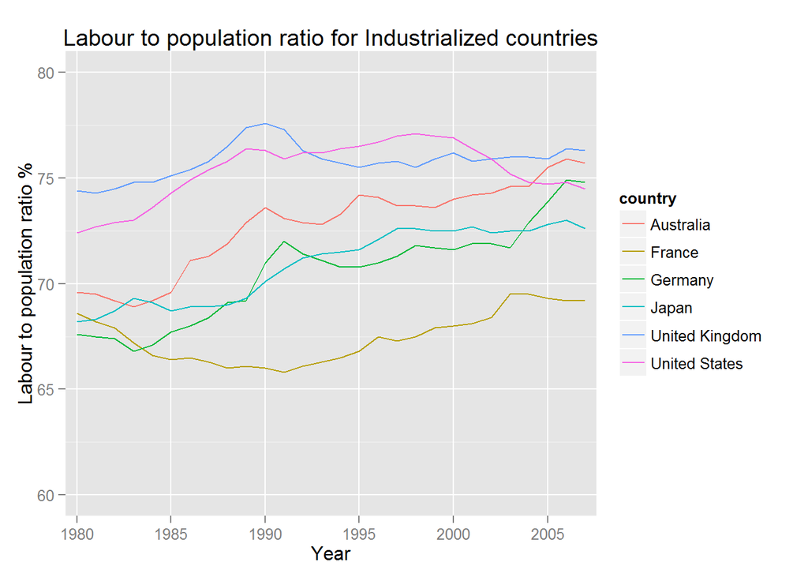

```r
industry_data=subset(mydata1, country %in% c("Australia", "France", "Germany", "Japan", "United Kingdom", "United States"))
ggplot(industry_data,aes(x=year, y=lp_ratio, group=country, color=country)) + geom_line() +
  ylab("Labour to population ratio %") +
  scale_x_discrete(breaks = seq(1980, 2010, 5)) +
  scale_y_continuous(limits=c(60, 80)) +
  xlab("Year") +
  ggtitle("Labour to population ratio for Industrialized countries")
```

### Industrialized countries line plot

> This line diagram shows the labour to population ratio were in the range 65%-77.6%.

> Most of these countries had a growing trend except United States which had decreasing ratio since year 2000. This could be due to baby-boomers started leaving work force. However, this assumption is not shared by other countries in this group.

> For United Kingdom, its ratio had a peak in 1990. Mrs. Thatcher left the prime minister role in 1990.

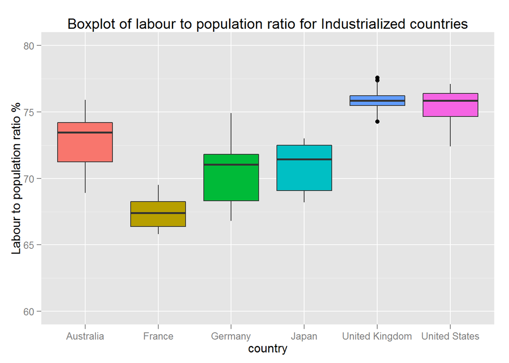

```r
ggplot(data=industry_data, aes(x=country, y=lp_ratio, fill=country)) + geom_boxplot() +
  ylab("Labour to population ratio %") +
  scale_y_continuous(limits=c(60, 80)) +
  guides(fill=FALSE) + ggtitle("Boxplot of labour to population ratio for Industrialized countries")
```

### Industrialized countries boxplot

> The boxplot for these Industrialized countries show the ratio range of each country. United Kingdom and United States have higher base while France had a low base.

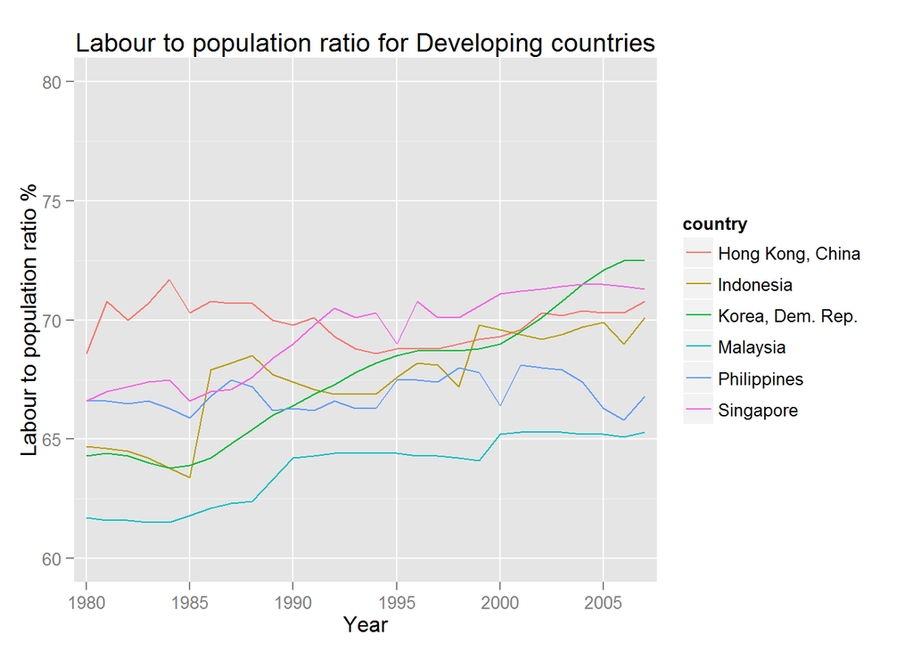

```r
developing_data=subset(mydata1, country %in% c("Hong Kong, China", "Korea, Dem. Rep.", "Indonesia", "Malaysia", "Philippines", "Singapore"))
ggplot(developing_data,aes(x=year, y=lp_ratio, group=country, color=country)) + geom_line() +
  ylab("Labour to population ratio %") +
  scale_x_discrete(breaks = seq(1980, 2010, 5)) +
  scale_y_continuous(limits=c(60, 80)) +
  xlab("Year") +
  ggtitle("Labour to population ratio for Developing countries")
```

### Developing countries line plot

> For these chosen Developing countries, the range of the ratios are between 62%-72.5% which is lower than the Industrialized countries.

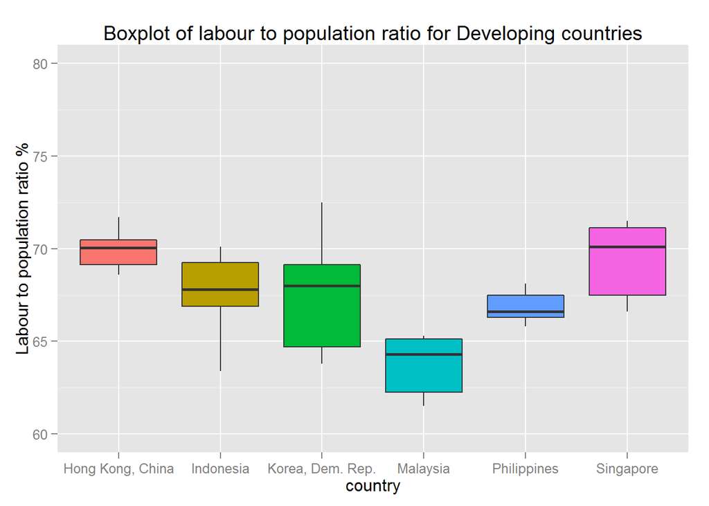

```r
ggplot(data=developing_data, aes(x=country, y=lp_ratio, fill=country)) + geom_boxplot() +
  ylab("Labour to population ratio %") +
  scale_y_continuous(limits=c(60, 80)) +
  guides(fill=FALSE) + ggtitle("Boxplot of labour to population ratio for Developing countries")
```

### Developing countries boxplot

> The boxplots for these Developing countries show the lower ratio base than Industrialized countries as well.

### Summary

> The above plots show the labour to population ratio trend difference between industrialized countries and developing countries. We can see how the economy related to the labour to population ratio. The data covers only from 1980 to 2007. It will be interesting to see what happened during GFC and after if we have that data available.